# Data Management and Introduction to R

Nathaly Guerrero

June 8, 2017

Based on: http://www.datacarpentry.org/lessons/

.

## Data Management

.

#### **Why?**

##### Data organization is the foundation of any research project

##### 80 % of data analysis is used cleaning and preparing the data (Dasu and Johnson 2003 in: Wickham, 2014)

.

#### **How?**

##### Spreadsheets (Excel, gnumeric, OpenOffice)

.

### 1. Good data entry practices

.

#### **Set up well-formatted tables before you start entering the data**

.

#### **How to structure your data?**

.

##### Ability to work with your data in other programs, clarity (for yourself in the future and for others)

.

#### **Rules:**

.

##### 1. Put the variables in columns- measurements, e.g. weight

##### 2. Put each observation in its own row

##### 3. Do not combine multiple information in one cell, e.g. Species_Sex

##### 4. Leave the raw data raw!

##### 5. Export the cleaned data to a text-based format like CSV (comma-separated values). Good for statistical analysis and data repositories

.

##### **Example: small mammal community in southern Arizona**

| Data collected | Plot | Species | Sex | Weigth |
| --- | --- | --- | --- | --- |
| 1/9/78 | 1 | DM | M | 40 |
| 1/9/78 | 1 | DM | F | 36 |
| 1/9/78 | 1 | DS | M | 135 |
| … |  |  |  |  |

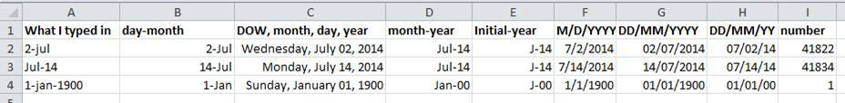

http://www.datacarpentry.org/spreadsheet-ecology-lesson/03-dates-as-data/

.

#### Remember: Columns for variables, row for observations, and cell for data values

More info: Hadley Wickham, Tidy Data, Vol. 59, Issue 10, Sep 2014, Journal of Statistical Software. http://www.jstatsoft.org/v59/i10.

. . . .

#### Leave the raw data raw! and keep track

.

##### The evolution of the spreadsheet

. .

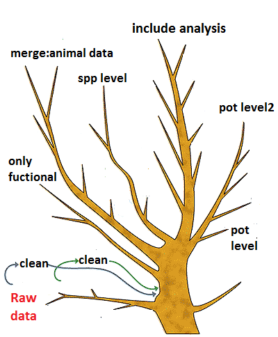

.

#### Don’t modify the original dataset! Create a new file for cleaned or analyzed data.

#### Keep tracks of the steps you took in the clean up or analysis!

##### Dimensions of spreedsheet, description of the change (e.g. new columns, merge with other datasets, subsets)

.

#### Create back-up copies often (in-site and off-site)

. .

### 2. How to avoid common formatting mistakes

.

#### Avoid using multiple tables within one spreadsheet

.

.

#### Avoid spreading data across multiple tabs

.

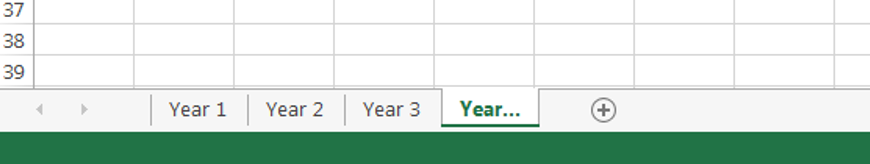

.

.

#### Record zeros as zeros and use an appropriate null value to record missing data

.

#### To the computer, a zero is actually data while a blank cell means that it was not measured (null value).

.

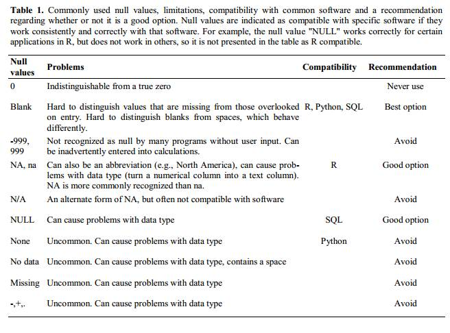

White et al, 2013, explain good choices for indicating null values for different software applications in their article: Nine simple ways to make it easier to (re)use your data. Ideas in Ecology and Evolution.

. .

#### Don’t use formatting to convey information or to make your spreadsheet look pretty

.

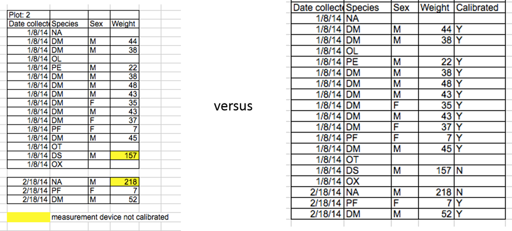

.

#### Place comments in a separate column

.

#### Record units in column headers not in cells

.

#### Include only one piece of information in a cell

.

#### Example: You find one male, and one female of the same species. You enter this as 1M, 1F.

#### Solution: Include one column for number of individuals and a separate column for sex.

.

#### Avoid spaces, numbers and special characters in column headers

.

#### Underescores (_) are good alternatives to spaces.

#### Writing names in Camel case (e.g. ExampleFileName)

#### Abreviations can not make sense in the future

#### Informative names

.

| Good Name | Good Alternative | Avoid |
| --- | --- | --- |
| Max_temp_C | MaxTemp | Maximum Temp (°C) |
| Mean_year_growth | MeanYearGrowth | Mean growth/year |
| weight | weight | w. |
| sex | sex | M/F |
| Observation_01 | first_observation | 1st Obs |

.

#### Avoid special characters in your data

#### Avoid adding characters such as newlines, tabs, and vertical tabs. Text cell may only contain text and spaces.

.

#### Record metadata in a separate plain text file

#### Metadata is a key part but do not include it as a legend in the top or bottom of your table

.

### 3. Quality control

.

#### Quality assurance: prior to data entering

.

##### 1.Select the column(s)that you want to validate

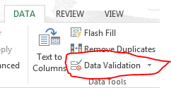

.

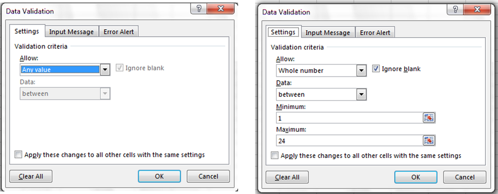

.

.

.

.

Error:

[figure not shown]

. .

customize the message:

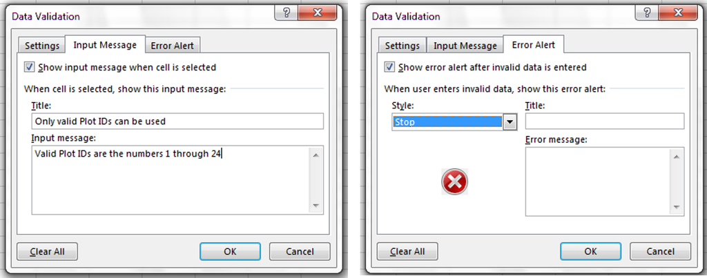

.

#### Quality control: check for errors

##### R - Graphs

.

.

### 4. What is a metadata?

Based on: https://www.dataone.org/sites/all/documents/best_pract_cook_20100729.pdf and http://researchdata.wisc.edu/metadata/

.

[figure not shown]

#### How, who, where, why, what, when… of the data

#### These information would allow you to find, understand, and use the data (In 20 years).

#### Understandable for a person not familiar with the experiment, methods, project.

#### Start early

. .

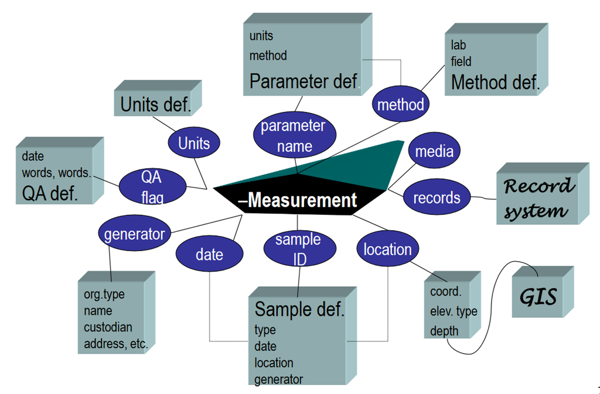

taken from:https://www.dataone.org/sites/all/documents/best_pract_cook_20100729.pdf

#### Examples of Metadata standard: Dublin Core (Dryad), Ecology metadata language (EML, Ecological Society of America).

#### Example of metadata:

http://onlinelibrary.wiley.com/doi/10.1890/0012-9623(2005)86%5b158:MTVOED%5d2.0.CO%3b2/epdf

.

.